# Project 2 - 1.Pharma

Ben Inbar

10/9/22

##### Choose any three of the “wide” datasets identified in the Week 6 Discussion items. (You may use your own dataset; please don’t use my Sample Post dataset, since that was used in your Week 6 assignment!) For each of the three chosen datasets: 1) Create a .CSV file (or optionally, a MySQL database!) that includes all of the information included in the dataset. You’re encouraged to use a “wide” structure similar to how the information appears in the discussion item, so that you can practice tidying and transformations as described below. 2) Read the information from your .CSV file into R, and use tidyr and dplyr as needed to tidy and transform your data. [Most of your grade will be based on this step!] 3) Perform the analysis requested in the discussion item.

Read in Jawaid Hakim’s pharmaceutical drug spending .csv and check.

```r
library(tidyverse)
library(ggplot2)
data <- read.csv("https://raw.githubusercontent.com/beninbar/DATA-607/main/Project%202/Pharma%20spend%20by%20country.csv")
head(data)
```

```
##   LOCATION TIME PC_HEALTHXP PC_GDP USD_CAP FLAG_CODES TOTAL_SPEND
## 1      AUS 1971      15.992  0.727  35.720                 462.11
## 2      AUS 1972      15.091  0.686  36.056                 475.11
## 3      AUS 1973      15.117  0.681  39.871                 533.47
## 4      AUS 1974      14.771  0.755  47.559                 652.65
## 5      AUS 1975      11.849  0.682  47.561                 660.76
## 6      AUS 1976      10.920  0.630  46.908                 658.26
```

Fortunately, this dataset is already relatively tidy and well-suited to analysis. But one problem that is immediately clear is that the number of observations for each country differs. Perhaps worse, some countries have data for differing years. 47 different years are represented, but not all countries are represented in each year.

```r
data |> summarize(countries = count(data, LOCATION))
```

```
##    countries.LOCATION countries.n
## 1                 AUS          44
## 2                 AUT          26
## 3                 BEL          41
## 4                 CAN          45
## 5                 CHE          31
## 6                 CZE          26
## 7                 DEU          45
## 8                 DNK          36
## 9                 ESP          32
## 10                EST          17
## 11                FIN          46
## 12                FRA          30
## 13                GBR          31
## 14                GRC          27
```

[output cut: 18 more lines]

```r
data |> summarize(countries = count(data, TIME))
```

```
##    countries.TIME countries.n
## 1            1970          11
## 2            1971          11
## 3            1972          11
## 4            1973          11
## 5            1974          11
## 6            1975          13
## 7            1976          13
## 8            1977          13
## 9            1978          13
## 10           1979          13
## 11           1980          18
## 12           1981          17
## 13           1982          17
## 14           1983          17
```

[output cut: 33 more lines]

We can try plotting this anyway, per Jawaid’s suggestions, just to see what it looks like visually. Note that figuring out how best to add labels took a while! They work, but in future would like cleaner ones. To position them properly, I generated a summarized tibble extracted from the larger dataset to pull from.

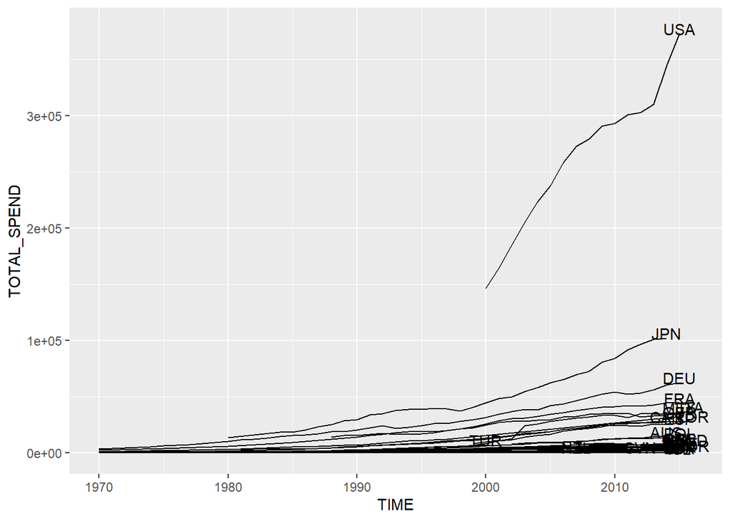

```r
for_label <- data |> group_by(LOCATION) |> summarize(year=max(TIME), totalspend=max(TOTAL_SPEND))

ggplot(data=data, aes(x=TIME, y=TOTAL_SPEND, group=LOCATION)) +
  geom_line() +
  geom_text(data=for_label, aes(x=year, y=totalspend + 4000, label=LOCATION))
```

The USA is clearly far and away the biggest phara drug spender. We can remove USA to get a better look at the trends in the rest of the countries.

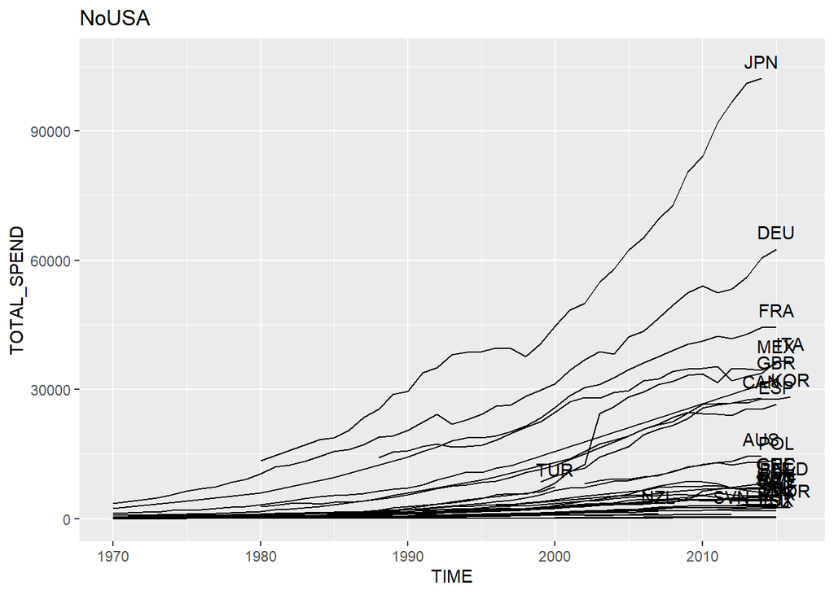

```r
noUSA <- filter(data, LOCATION!="USA")
for_labelnoUSA <- noUSA |> group_by(LOCATION) |> summarize(year=max(TIME), totalspend=max(TOTAL_SPEND))

ggplot(data=noUSA, aes(x=TIME, y=TOTAL_SPEND, group=LOCATION)) +
  geom_line() +
  geom_text(data=for_labelnoUSA, aes(x=year, y=totalspend + 4000, label=LOCATION)) +
  ggtitle("NoUSA")
```

For Jawaid’s other suggestion of comparing growth in spend between countries, I took the difference between the max and min in TOTAL_SPEND for each country across all years, and graphed.

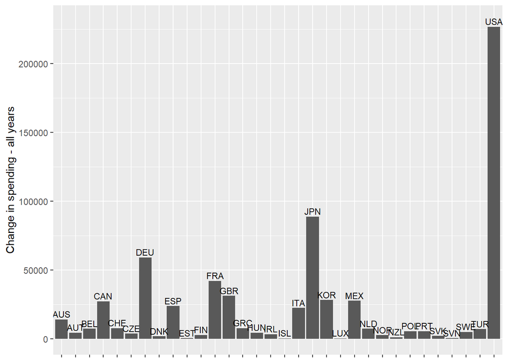

```r
growth <- data |> group_by(LOCATION) |> summarize(growth=max(TOTAL_SPEND) - min(TOTAL_SPEND))
ggplot(data=growth, aes(x=LOCATION, y=growth)) +
  geom_bar(stat="identity") +
  geom_text(data=growth, aes(x=LOCATION, y=growth + 4000, label=LOCATION), size=3) +
  theme(axis.text.x=element_blank(), axis.title.x=element_blank()) +
  labs(y="Change in spending - all years")
```

##### Once again we see that the US far eclipses other countries, not only in total spend but in growth in spending over time.